# ESTIMATE tumor purity of bulk expression data

Steven Foltz

This notebook uses [ESTIMATE](https://www.nature.com/articles/ncomms3612) ([R package](https://r-forge.r-project.org/projects/estimate/) v1.0.13) to predict the tumor purity of our bulk array and RNA-seq gene expression samples. Tumors of different purity levels may interact differently with subgroup prediction models. Single sample predictors *should* allow for more robust performance with wider ranges of tumor purity because the within-sample relationships between genes should remain consistent even when the sample has some normal tissue signal.

# Setup

```r
# Load packages
suppressMessages(library(magrittr))
suppressMessages(library(estimate))
source(here::here("utils", "convert_gene_names.R"))

# Set up directories and file names
processed_data_dir <- here::here("processed_data")
plot_dir <- here::here("plots")
estimate_data_dir <- file.path(processed_data_dir, "estimate")
estimate_plot_dir <- file.path(plot_dir, "estimate")

# bulk gene expression and metadata file names
genex_input_filename <- file.path(processed_data_dir, "bulk_genex.tsv")
metadata_input_filename <- file.path(processed_data_dir, "bulk_metadata.tsv")

# files used by ESTIMATE functions
estimate_input_filename <- file.path(estimate_data_dir, "estimate_input.tsv")
estimate_input_gct_filename <- file.path(estimate_data_dir, "estimate_input.gct")

# files produced by ESTIMATE functions (.gct) and after some reshaping (.tsv)
estimate_results_output_gct_filename <- file.path(estimate_data_dir, "estimate_results.gct")
estimate_results_output_filename <- file.path(estimate_data_dir, "estimate_results.tsv")

# output plot file names
tumor_purity_plot_filename <- file.path(estimate_plot_dir, "tumor_purity_by_subgroup.pdf")
stromal_immune_plot_filename <- file.path(estimate_plot_dir, "stromal_score_by_immune_score.pdf")
estimate_score_tumor_purity_plot_filename <- file.path(estimate_plot_dir, "estimate_score_by_tumor_purity.pdf")

# Read in bulk genex and metadata
genex_df <- readr::read_tsv(genex_input_filename,
                            show_col_types = FALSE) |>
  tibble::column_to_rownames(var = "gene")

metadata_df <- readr::read_tsv(metadata_input_filename,
                               show_col_types = FALSE)

# Reformat genex data by converting ENSEMBL gene IDs to SYMBOL

# convert gene names
set_up_AnnotationHub(ah_date = "2022-10-30")

genex_df_SYMBOL <- genex_df |>
  tibble::rownames_to_column(var = "ENSEMBL") |>
  convert_gene_names(gene_column_before = "ENSEMBL",
                     gene_column_after = "SYMBOL",
                     map_from = "ENSEMBL",
                     map_to = "SYMBOL",
                     ah_date = "2022-10-30")

readr::write_tsv(x = genex_df_SYMBOL,
                 file = estimate_input_filename)

# convert gene expression tsv to GCT file
# filterCommonGenes reduces the input to only include genes used in ESTIMATE model
estimate::filterCommonGenes(input.f = estimate_input_filename,
                            output.f = estimate_input_gct_filename,
                            id = "GeneSymbol") # "EntrezID" did not work
```

```
## [1] "Merged dataset includes 9011 genes (1401 mismatched)."
```

# Run ESTIMATE

[ESTIMATE](https://www.nature.com/articles/ncomms3612) generates Stromal and Immune scores using [ssGSEA](https://www.genepattern.org/modules/docs/ssGSEAProjection/4#gsc.tab=0), regardless of platform:

Stromal + Immune scores = ESTIMATE score

The model converting ESTIMATE scores to tumor purity was trained on Affymetrix data. That model is:

$\text{Tumor Purity} = cos(0.6049872018 + 0.0001467884 * \text{ESTIMATE})$

To return tumor purity scores, we must set platform = “affymetrix” (default) even though some data are RNA-seq, otherwise the tumor purity conversion is not done.

```r
estimate::estimateScore(input.ds = estimate_input_gct_filename,
                        output.ds = estimate_results_output_gct_filename,
                        platform = "affymetrix")
```

```
## [1] "1 gene set: StromalSignature  overlap= 132"
## [1] "2 gene set: ImmuneSignature  overlap= 131"
```

### Reshape ESTIMATE GCT file into something tidy

[Broad data formats](https://software.broadinstitute.org/cancer/software/gsea/wiki/index.php/Data_formats)

There are four variables (Stromal, Immune, ESTIMATE, and tumor purity) associated with each observation (one sample) but GCT is an untidy format and we need to skip the first two metadata lines (version and data dimensions).

We need to convert from this:

| #1.2 | blank | blank | blank |
| --- | --- | --- | --- |
| n_features | n_samples | blank | blank |
| NAME | Description | sample1 | sample2 |
| StromalScore | StromalScore | w1 | w2 |
| ImmuneScore | ImmuneScore | x1 | x2 |
| ESTIMATEScore | ESTIMATEScore | y1 | y2 |
| TumorPurity | TumorPurity | z1 | z2 |

Into this (intermediate step):

| NAME | sample_accession | value |
| --- | --- | --- |
| StromalScore | sample1 | w1 |
| ImmuneScore | sample1 | x1 |
| ESTIMATEScore | sample1 | y1 |
| TumorPurity | sample1 | z1 |
| StromalScore | sample2 | w2 |
| ImmuneScore | sample2 | x2 |
| ESTIMATEScore | sample2 | y2 |
| TumorPurity | sample2 | z2 |

Into this (tidy format):

| sample_accession | StromalScore | ImmuneScore | ESTIMATEScore | TumorPurity |
| --- | --- | --- | --- | --- |
| sample1 | w1 | x1 | y1 | z1 |
| sample2 | w2 | x2 | y2 | z2 |

```r
estimate_df <- readr::read_tsv(estimate_results_output_gct_filename,
                               show_col_types = FALSE,
                               skip = 2) |> # skip two metadata lines
  dplyr::select(-Description) |> # Description column is redundant
  tidyr::pivot_longer(cols = -NAME, #create a column of sample accessions
                      names_to = "sample_accession") |>
  tidyr::pivot_wider(names_from = NAME, # collect variables from each sample
                     values_from = value) # into a single row

readr::write_tsv(x = estimate_df,
                 file = estimate_results_output_filename)
```

# Visualize results

### Set up plot data and theme

```r
estimate_metadata_plot_df <- estimate_df |>
  dplyr::left_join(metadata_df,
                   by = "sample_accession") |>
  dplyr::filter(!is.na(subgroup))

# set a consistent baseline theme
ggplot2::theme_set(ggplot2::theme_bw())
```

### Plot tumor purity violins

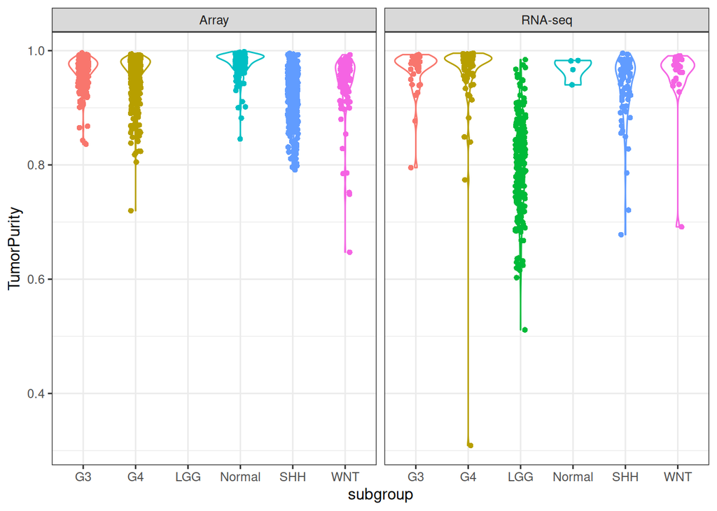

```r
tumor_purity_plot_object <- estimate_metadata_plot_df |>
  ggplot2::ggplot(ggplot2::aes(x = subgroup,
                               y = TumorPurity,
                               color = subgroup)) +
  ggplot2::geom_violin(show.legend = FALSE) +
  ggplot2::geom_jitter(shape = 16,
                       height = 0,
                       width = 0.1,
                       show.legend = FALSE) +
  ggplot2::facet_wrap(ggplot2::vars(platform))

ggplot2::ggsave(filename = tumor_purity_plot_filename,
                plot = tumor_purity_plot_object,
                width = 7.5,
                height = 7.5)

tumor_purity_plot_object
```

### Plot stromal vs. immune scores

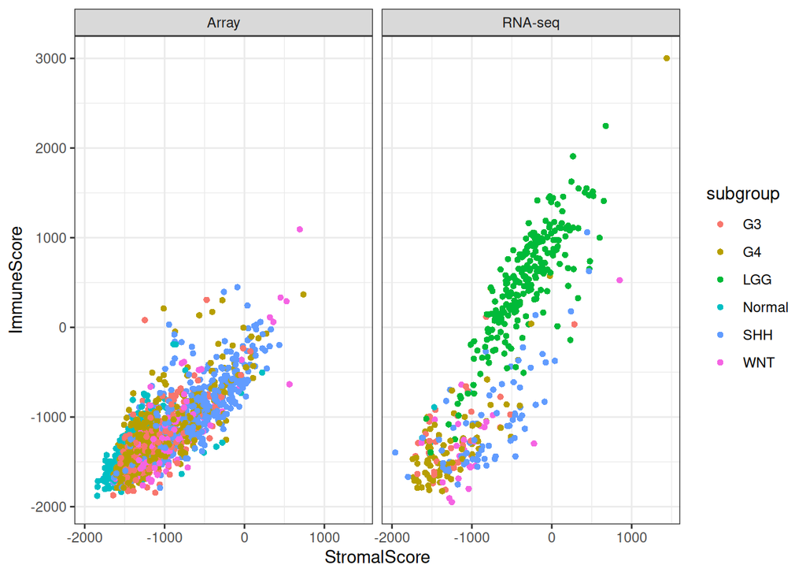

```r
stromal_immune_plot_object <- estimate_metadata_plot_df |>
  ggplot2::ggplot(ggplot2::aes(x = StromalScore,
                               y = ImmuneScore,
                               color = subgroup)) +
  ggplot2::geom_point(shape = 16) +
  ggplot2::facet_wrap(ggplot2::vars(platform))

ggplot2::ggsave(filename = stromal_immune_plot_filename,
                plot = stromal_immune_plot_object,
                width = 7.5,
                height = 7.5)

stromal_immune_plot_object
```

- There is little differentiation between MB subgroups in their stromal and immune scores
- LGG samples tend of have higher stromal and immune scores than the MB samples

### Plot estimate score vs. tumor purity

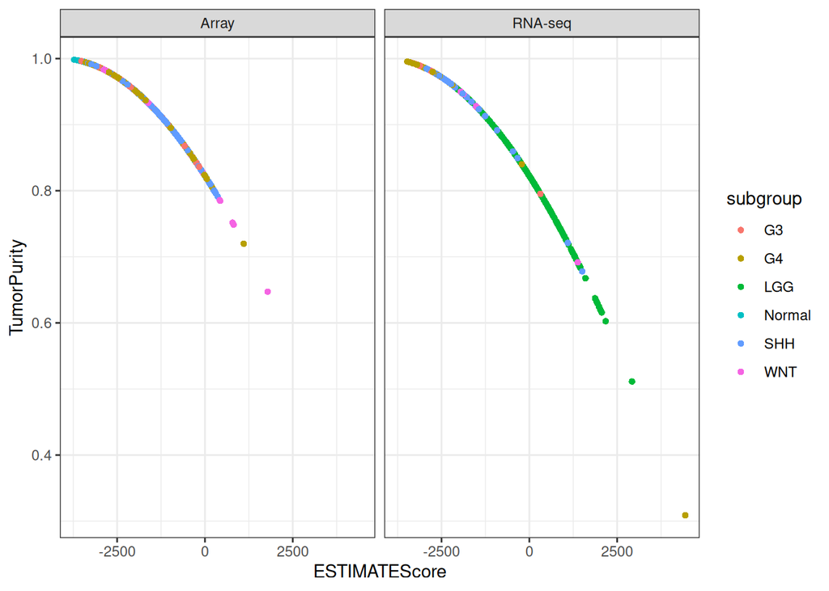

```r
estimate_score_tumor_purity_plot_object <- estimate_metadata_plot_df |>
  ggplot2::ggplot(ggplot2::aes(x = ESTIMATEScore,
                               y = TumorPurity,
                               color = subgroup)) +
  ggplot2::geom_point(shape = 16) +
  ggplot2::facet_wrap(ggplot2::vars(platform))

ggplot2::ggsave(filename = estimate_score_tumor_purity_plot_filename,
                plot = estimate_score_tumor_purity_plot_object,
                width = 7.5,
                height = 7.5)

estimate_score_tumor_purity_plot_object
```

- ESTIMATE scores are calculated as Stromal + Immune scores = ESTIMATE score
- Tumor purity is calculated as $\text{Tumor Purity} = cos(0.6049872018 + 0.0001467884 * \text{ESTIMATE})$